```r
library(data.table)
library(stringr)
library(dplyr)
library(RGenetics)
library(ape)
library(seqinr)
library(ggtree)
library(ggplot2)
library(ggbiplot)
library(ggbeeswarm)
library(ggpubr)
library(factoextra)
library(directlabels)
library(latex2exp)
```

# Part 0. Ready to start

This is a code, used for analysis of B cell clonal lineages and visualisation of results in the study, named “Memory persistence and positively selected transition to antibody-secreting subsets in longitudinal lGH repertoires”. To run this code we used R version 4.0.0 (2020-04-24) and the list of R packages of following version:

```r
packages <- data.frame(name = c("data.table", "stringr", "dplyr", "RGenetics", "ape", "seqinr", "ggtree", "ggplot2", "ggbiplot", "ggbeeswarm", "ggpubr", "factoextra", "directlabels", "latex2exp"))
for (i in packages$name) {packages$version[packages$name == i] <- as.character(packageVersion(i))}
packages
```

```
##            name   version
## 1    data.table    1.13.0
## 2       stringr     1.4.0
## 3         dplyr     1.0.2
## 4     RGenetics       0.1
## 5           ape     5.4.1
## 6        seqinr     3.6.1
## 7        ggtree     2.2.4
## 8       ggplot2     3.3.2
## 9      ggbiplot      0.55
## 10   ggbeeswarm     0.6.0
## 11       ggpubr     0.4.0
## 12   factoextra     1.0.7
## 13 directlabels 2020.6.17
## 14    latex2exp     0.4.0
```

The code assumes, that the working directory contains following objects:

**whole_reperotires** - whole repertoires in the format of MiXCR output;

**alignments** - alignments of B-cell clonal lineages with the predicted MRCA and germline sequences in FASTA format;

**trees** - phylogenetic trees of B-cell lineages with the germline sequence as an outgroup in newick format;

**G-MRCA** - aligments of the germline sequence with MRCA in FASTA format;

**timepoint.csv** - correspondence of the number of sampling time points to real dates for eacg donor;

```r
head(timepoints)
```

```
##   Patient Timepoint       Date
## 1     MRK       p01 2017-04-06
## 2     MRK       p02 2017-05-15
## 3     MRK       p03 2018-03-16
## 4      IM       p01 2017-04-06
## 5      IM       p02 2017-05-15
## 6      IM       p03 2018-03-13
```

**table_of_repeats.rds** - the list of clonotypes with the same BCR sequence, but came from different time point / cell subsets / isotypes.

```r
head(repeats)
```

```
##   pat   id                   sum_name
## 1  AT  526  489_5_isot_3_L_2017-05-26
## 2  AT  526 1475_5_isot_3_L_2017-04-10
## 3  AT  526 2273_5_isot_1_B_2018-03-23
## 4  AT 3440 5897_5_isot_3_B_2018-03-23
## 5  AT 3440 8397_5_isot_3_B_2017-04-10
## 6  AT 3440  703_5_isot_3_L_2017-04-10
##                                                                                                      un_names
## 1                                                         557_1_isot_3_L_2017-04-10R489_1_isot_3_L_2017-05-26
## 2                                                       2697_1_isot_3_P_2017-04-10R1475_1_isot_3_L_2017-04-10
## 3 1471_1_isot_1_B_2017-04-10R8133_1_isot_1_B_2017-05-26R5577_2_isot_3_B_2017-05-26R2273_1_isot_1_B_2018-03-23
## 4                                                        215_1_isot_3_L_2017-04-10R5897_1_isot_3_B_2018-03-23
## 5                                                        367_1_isot_3_P_2017-04-10R8397_1_isot_3_B_2017-04-10
## 6                                                          39_1_isot_3_P_2017-04-10R703_1_isot_3_L_2017-04-10
##                   clone
## 1  AT_clone_526_size_32
## 2  AT_clone_526_size_32
## 3  AT_clone_526_size_32
## 4 AT_clone_3440_size_28
## 5 AT_clone_3440_size_28
## 6 AT_clone_3440_size_28
```

**path** - patient;

**id** - if of a clonal lineage;

**sum_name** reflects how BCR sequence of these clonotypesis named in the alignment and phylogenetic tree;

**un_names** shows indetificators of clonotypes, having this BCR sequnece, listed via R symbol;

**clone** - full name of a clonal lineage (== filename of corresponding alignment).

The name of clonotypes is coded as the following: **367_1_isot_3_P_2017-04-10**, where

**367_** - identificator of the clonotype;

**1_** - numer of technical replica (if 1 or 2), or the sign that is it a sum name for several clonotypes (if 5);

**isot-3** - isotype (1 for IG M, 2 for Ig G and 3 for Ig A);

**P_** - cell subset (B for Bmem, P for plasmablasts and L for plasma cells);

**2017-04-10** - date of the sampling.

To run it first define the path of your working directory and dataframes, described above:

```r
path <- "/home/jane/PhD_Skoltech/AF_work/Cell_fractions/no_p04/beauty_code/"
timepoints <- fread(paste0(path, "timepoints.csv"), data.table = FALSE)
repeats <- readRDS(paste0(path, "table_of_repeats.rds"))
```

# Part 1. Temporal dynamics of clonal groups is associated with cell subset composition

### (Results from Figure 3 and Supplementary Figure 4)

### Analysis of lineage composition and persistence, PCA clustering of clonal lineages in HBmem and LBmem clusters

```r
lineage_composition <- data.frame(file = list.files(paste0(path, "alignments/"), pattern = "vj.fas"),
                     lineage_id = substring(str_extract(list.files(paste0(path, "alignments/"),
                                                      pattern = "vj.fas"), "e_[0-9]*"), 3),
                     patient = str_extract(list.files(paste0(path, "/alignments/"), pattern = "vj.fas"), "[A-Z]*"))

composition <- c()
for (p in unique(lineage_composition$patient)){
  df <- fread(paste0(path, "whole_repertoires/", p, "_grouped.txt"), data.table = FALSE)
  df <- data.frame(df)

  ## clonal fractions in repertoire
  p1 <- nrow(df[df$timepoint == "p01",])
  p2 <- nrow(df[df$timepoint == "p02",])
  p3 <- nrow(df[df$timepoint == "p03",])

  ## pseudocounts
  ps_1 <- 1/p1
  ps_2 <- 1/p2
  ps_3 <- 1/p3

  for (cl in lineage_composition$lineage_id[lineage_composition$patient == p]){
    lineage <- df[df$clonalGroupId == cl & df$donor == p,]
    size <- nrow(lineage)
    size_un <- length(unique(lineage$nSeqVDJRegion))
    fr_time <- c(length(lineage$timepoint[lineage$timepoint == "p01"])/p1 + ps_1,
                   length(lineage$timepoint[lineage$timepoint == "p02"])/p2 + ps_2,
                   length(lineage$timepoint[lineage$timepoint == "p03"])/p3 + ps_3)

    sort_fr <- sort(fr_time)
    persistency <- 1/mean(c(sort_fr[3]/sort_fr[1], sort_fr[3]/sort_fr[2]))

    pbl <- length(lineage$timepoint[lineage$subpop == "PBL"])/size
    pl <- length(lineage$timepoint[lineage$subpop == "PL"])/size
    bmem <- 1 - pbl - pl
    isot_md <- length(lineage$timepoint[lineage$bestCHit == "IGHM*00" | lineage$bestCHit == "IGHD*00"])/size
    isot_a <-  length(lineage$timepoint[lineage$bestCHit == "IGHA1*00" | lineage$bestCHit == "IGHA2*00"])/size
    isot_g <- 1 - isot_md - isot_a
    composition <- rbind(composition, c(persistency, fr_time, bmem, pbl, pl, isot_md, isot_g, isot_a,
                                        size_un))
  }
}

lineage_composition <-cbind(lineage_composition, composition)
colnames(lineage_composition) <- c("file", "lineage_id", "patient", "pers", "freq_T1", "freq_T2", "freq_T3", "Bmem", "PBL", "PL", "Ig M", "Ig G", "Ig A", "size")

lineage_composition[, c(1:14)] <- sapply(lineage_composition[, c(1:14)], as.character)
lineage_composition[, c(4:14)] <- sapply(lineage_composition[, c(4:14)], as.numeric)

# Compute k-means with k = 3
set.seed(123)
res.km <- kmeans(scale(lineage_composition[, 8:13]), 2, nstart = 25)
res.pca <- prcomp(lineage_composition[, 8:13],  scale = TRUE)
lineage_composition$cluster <- res.km$cluster
lineage_composition$cluster[lineage_composition$cluster == 1] <- "HBmem"
lineage_composition$cluster[lineage_composition$cluster == 2] <- "LBmem"
```

### Themes of plots used for data visualisation:

```r
my_theme <- theme_bw() +
                   theme(legend.position = "none",
                   legend.background = element_rect(),
                   legend.title = element_text (colour="black", size = 12, face = "plain"),
                   legend.text = element_text(colour="black", size = 12, face = "plain"),
                   plot.title = element_text(colour="black", size = 14, face = "bold"),
                   axis.title = element_text (colour="black", size = 12, face = "plain"),
                   axis.text = element_text(colour="grey20", size = 10, face = "plain"),
                   axis.line = element_line(colour="grey20", size = 0.6),
                   panel.background = element_rect(fill = "white", colour = "grey20"),
                   strip.text = element_text(size = 12))

my_colors <- list(scale_color_manual(values = c("HBmem" = "mediumpurple4",
                                                "LBmem" = "tan1")),
                   scale_fill_manual(values = c("HBmem" = "mediumpurple4",
                                                "LBmem" = "tan1")))

my_colors_isot <- list(scale_color_manual(values = c("Ig M" = "#D3DDDC",
                                                     "Ig G" = "#EBCC2A",
                                                     "Ig A" = "#E58601")),
                      scale_fill_manual(values = c("Ig M" = "#D3DDDC",
                                                     "Ig G" = "#EBCC2A",
                                                     "Ig A" = "#E58601")))


my_colors_fractions <- list(scale_color_manual(values = c("Bmem" = "#273046",
                                                          "PBL" = "#F8AFA8",
                                                          "PL" = "#CB2314")),
                            scale_fill_manual(values = c("Bmem" = "#273046",
                                                          "PBL" = "#F8AFA8",
                                                          "PL" = "#CB2314")))

my_shapes_patients <- list(scale_shape_manual(values = c(22, 21, 24, 23), name = "Patient"))

cluster_comparisons <- list(c("HBmem", "LBmem"))
```

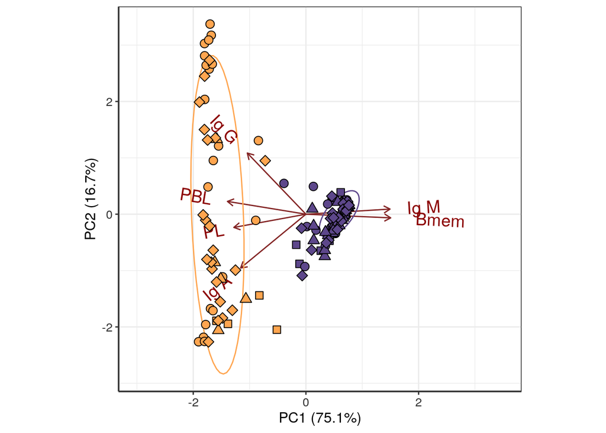

```r
p_pca <- ggbiplot(res.pca, groups = lineage_composition$cluster, varname.size = 5, ellipse = TRUE, ellipse.type = "convex", varname.adjust = 2) +
  geom_point(aes(shape=lineage_composition$patient,  fill = lineage_composition$cluster, alpha = lineage_composition$cluster), color = "black",
             size = 3) +
  scale_x_continuous(name = "PC1 (75.1%)", limits = c(-3, 3.5)) +
  scale_y_continuous(name = "PC2 (16.7%)") +
  scale_alpha_manual(values = c("2" = 0.5, "1" = 0.5)) +
  my_shapes_patients +
  my_colors +
  my_theme +
  theme(legend.position = "none")
p_pca
```

#### Fig. S4A: Scree plot for principal component analysi s from Fig. 3A of composition of clonal groups, where fractions of memory B cell, plasmablasts, plasma cells and fractions of IGHM, IGHG and IGHA were used as variables;

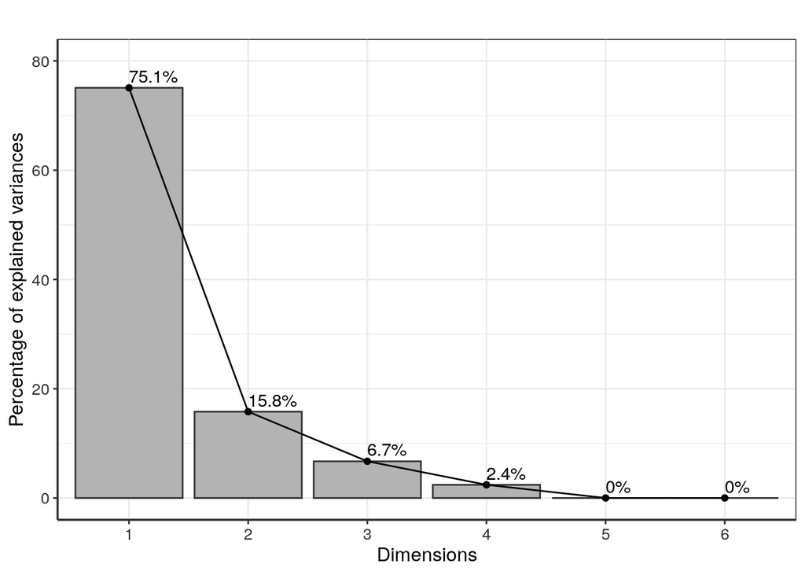

```r
p_scree <- fviz_eig(res.pca, addlabels=TRUE, barfill = "grey70", barcolor = "grey20") +
  ggtitle("") +
  ylim(0,80) + my_theme
p_scree
```

#### Fig. S4C: The number of clonal groups belonging to HBmem or LBmem clusters in each donor;

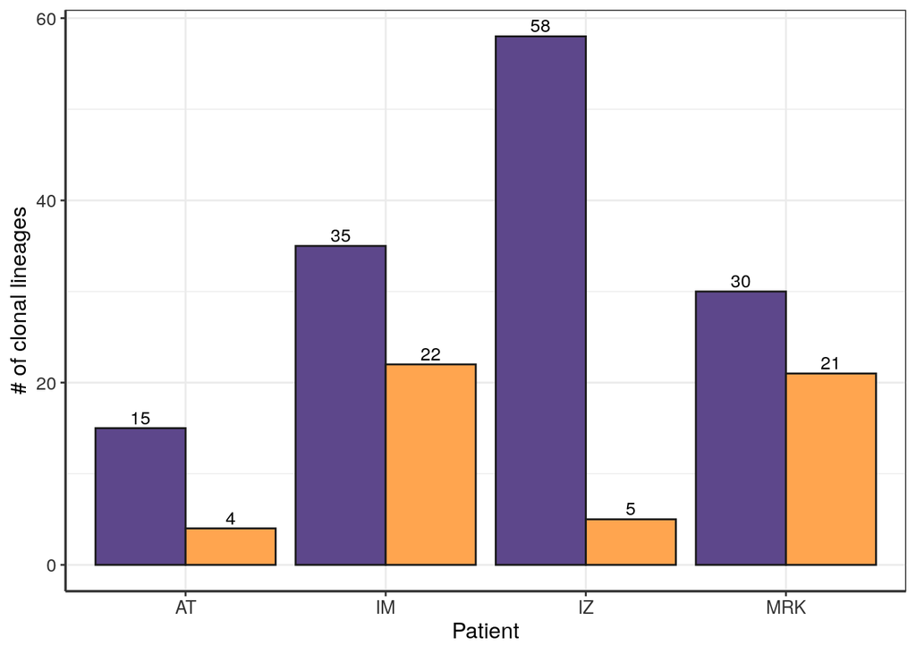

```r
p_n <- ggplot(plyr::count(lineage_composition[,c(3,15)]), aes(x = patient, y = freq, fill = cluster)) +
  geom_bar(stat="identity", position=position_dodge(), color = "grey10")+
  geom_text(aes(label=freq), vjust=-0.3, size=3.5,  position = position_dodge(0.9))+
  scale_y_continuous(name=("# of clonal lineages")) +
  scale_x_discrete(name = "Patient") +
  my_colors +
  my_theme +
  theme(legend.position = "none")
p_n
```

#### Fig. 3B: Proportion of clonotypes of a certain cell subset or isotype for clonal groups falling into HBmem or LBmem clusters; Statistical significance is the following: * - $p\leq0.05$, ** - $p\leq0.01$, *** - $p\leq10^{-3}$, **** - $p\leq10^{-4}$.

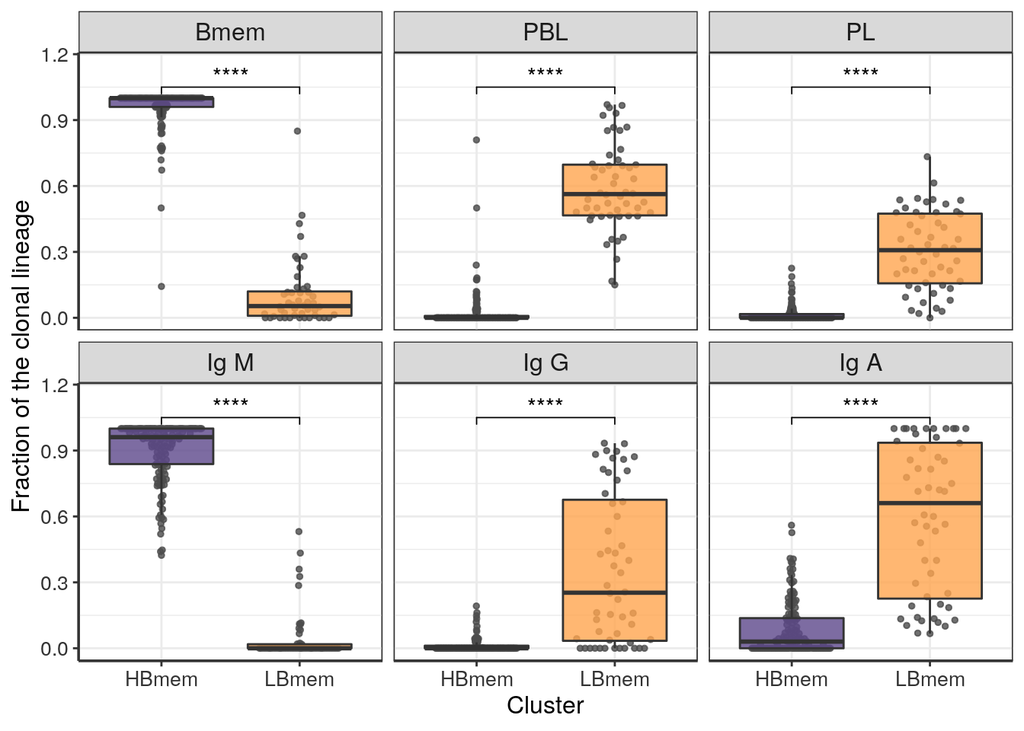

```r
p_comp <- lineage_composition %>% select(Bmem, PBL, PL, 'Ig M', 'Ig G', 'Ig A', cluster, patient) %>%  melt %>%
  ggplot(aes(x = cluster, y = value, fill = cluster)) +
  geom_quasirandom(width=0.3, size = 1, color = "grey30", alpha = 0.8) +
  geom_boxplot(alpha = 0.8, outlier.colour = NA) +
  stat_compare_means(comparisons = cluster_comparisons, method = "wilcox.test", size = 4, label = "p.signif") +
  scale_y_continuous(name=("Fraction of the clonal lineage"), limits = c(0, 1.15)) +
  scale_x_discrete(name = "Cluster") +
  my_colors +
  my_theme +
  theme(legend.position = "none") +
  facet_wrap(~variable)

p_comp
```

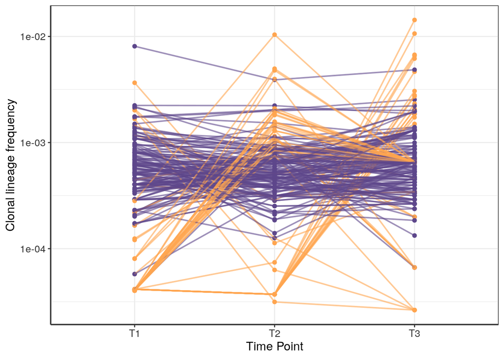

```r
lineage_composition %>%
  select(file, freq_T1, freq_T2, freq_T3, cluster) %>%
  melt %>%
  ggplot(aes(x = as.factor(variable), y = value, color = cluster, group = file)) +
  geom_point() +
  geom_line(alpha = 0.6, size = 0.7) +
  scale_x_discrete(name = "Time Point", labels = c("freq_T1" = "T1", "freq_T2" = "T2", "freq_T3" = "T3")) +
  scale_y_continuous(trans = "log10", name = "Clonal lineage frequency") +
  my_colors +
  my_theme -> p_traj
p_traj
```

#### Fig. 3D: A schematic representation of calculation of clonal group persistence. $f_{max}$ is the maximum clonal group frequency among the three time points, and $f_{ij}$ are frequencies at the remaining two timepoints;

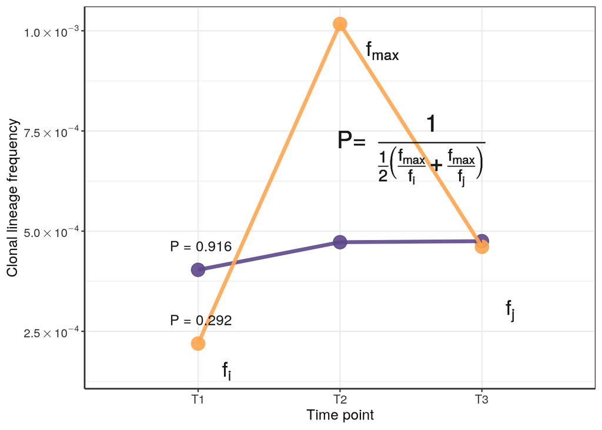

```r
hb_clone <- lineage_composition$lineage_id[lineage_composition$pers > 0.9][5]
lb_clone <- lineage_composition$lineage_id[lineage_composition$pers < 0.3][3]

df <- rbind(unname(cbind(c("T1", "T2", "T3"), rep("HBmem", 3),
                         as.character(lineage_composition[lineage_composition$lineage_id == hb_clone, 5:7]),
                   as.character(round(lineage_composition[lineage_composition$lineage_id == hb_clone, 4], digits=3)))),
            unname(cbind(c("T1", "T2", "T3"), rep("LBmem", 3),
                         as.character(lineage_composition[lineage_composition$lineage_id == lb_clone, 5:7]),
                   as.character(round(lineage_composition[lineage_composition$lineage_id == lb_clone, 4], digits=3)))))
df <- data.frame(df)
colnames(df) <- c("point", "group", "freq", "pers")
df$group <- as.factor(df$group)
df$pers <- paste0("P = ", df$pers)

fancy_scientific <- function(l) {
     # turn in to character string in scientific notation
     l <- format(l, scientific = TRUE)
     # quote the part before the exponent to keep all the digits
     l <- gsub("^(.*)e", "'\\1'e", l)
     # turn the 'e+' into plotmath format
     l <- gsub("e", "%*%10^", l)
     # return this as an expression
     parse(text=l)
}

p_eq <- ggplot(df, aes(x = point, y = as.numeric(as.character(freq)), color = group, group = group)) +
  geom_point(size = 5, alpha = 0.9) +
  geom_line(size = 1.5, alpha = 0.9) +
  geom_dl(aes(label = pers), method = list(dl.trans(x = x + 1, y = y + 0.7), "first.points"), size = 12, color = "grey10") +
  geom_text(aes(2.5,0.0007, label=("P*\'=\'~frac(1,frac(1,2)(frac(f[max],f[i])+frac(f[max],f[j])))")),
            parse = TRUE, size = 7, color = "grey10") +
  geom_text(aes(2.3,0.00095, label=("f[max]")), parse = TRUE, size = 6, color = "grey10") +
  geom_text(aes(1.2,0.00015, label=("f[i]")), parse = TRUE, size = 6, color = "grey10") +
  geom_text(aes(3.2,0.0003, label=("f[j]")), parse = TRUE, size = 6, color = "grey10") +
  scale_y_continuous(name=("Clonal lineage frequency"), labels=fancy_scientific) +
  scale_x_discrete(limits = c("T1", "T2","T3"), expand=c(0.2, 0.4), name = "Time point") +
  my_colors +
  my_theme

p_eq
```

#### Fig. 3F: Comparison of persistence between HBmem and LBmem clonal groups. Statistical significance is calculated by Mann-Whitney test, notation is the following: * - $p\leq0.05$, ** - $p\leq0.01$, *** - $p\leq10^{-3}$, **** - $p\leq10^{-4}$.

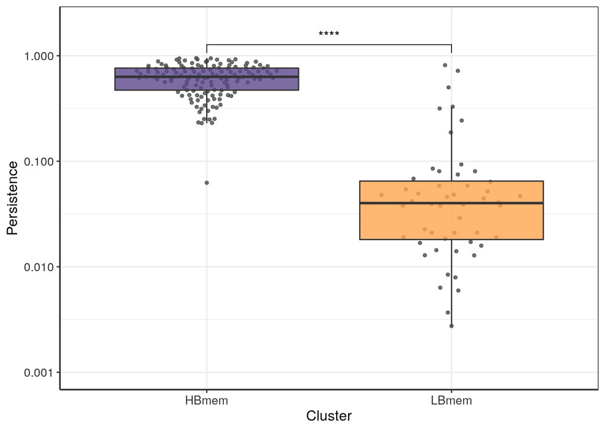

```r
p_pers <- ggplot(lineage_composition, aes(x = cluster, y = pers, fill = cluster)) +
  geom_quasirandom(width=0.3, size = 1, color = "grey30", alpha = 0.8) +
  geom_boxplot(alpha = 0.8, outlier.colour = NA) +
  stat_compare_means(comparisons = cluster_comparisons, method = "wilcox.test", size = 4, label = "p.signif") +
  scale_y_log10(name=("Persistence"), limits = c(0.001, 2)) +
  scale_x_discrete(name = "Cluster") +
  my_colors +
  my_theme

p_pers
```

#### Fig. 3E: Spearman’s correlation between persistence of the clonal group and fractions of its clonotypes attributed to the different B cell subpopulations or with a particular isotype; Statistical significance is the following: * - $p\leq0.05$, ** - $p\leq0.01$, *** - $p\leq10^{-3}$, **** - $p\leq10^{-4}$.

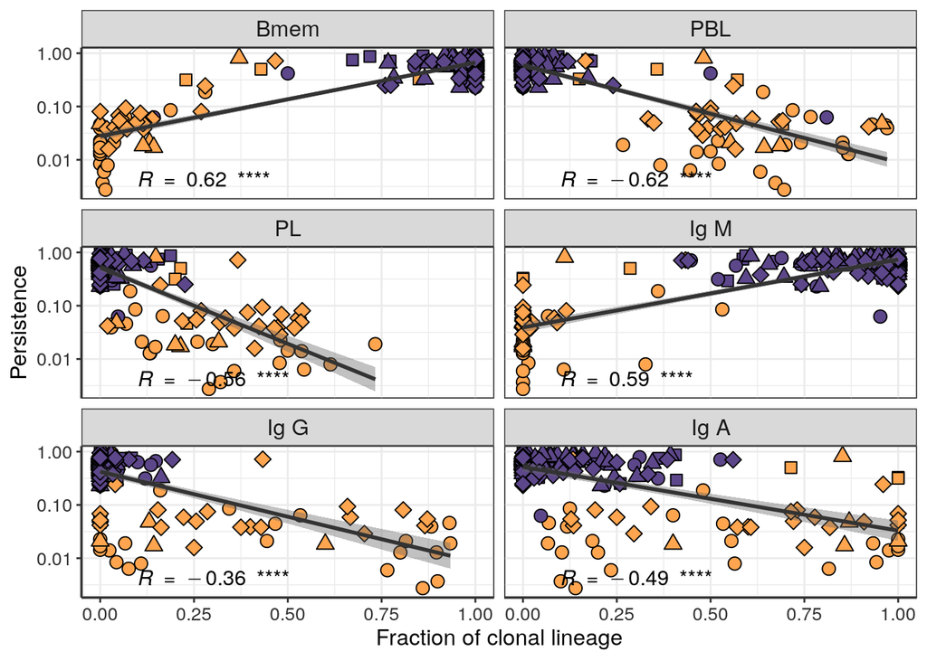

```r
df_x <- lineage_composition %>% select(patient, Bmem, PBL, PL, 'Ig M', 'Ig G', 'Ig A', cluster) %>% melt
df_x$pers <- rep(lineage_composition$pers, 6)

p_corr <- ggplot(df_x, aes(x = value, y = pers)) +
  geom_point(aes(fill = cluster, shape = patient, alpha = cluster), size = 3,  color = "black") +
  geom_smooth(method = 'lm', color = "grey20", fill = "grey40") +
  my_shapes_patients +
  stat_cor(method="spearman", size = 4, label.x.npc = 0.1, label.y.npc = 0.1,
          aes(label = paste(..r.label.., cut(..p.., breaks = c(-Inf, 0.0001, 0.001, 0.01, 0.05, Inf),
                                            labels = c("'****'", "'***'", "'**'", "'*'", "'ns'")),
                            sep = "~"))) +
  my_colors +
  scale_y_continuous(trans = "log10", name=("Persistence")) +
  scale_x_continuous(name = "Fraction of clonal lineage") +
  scale_alpha_manual(values = c("2" = 0.7, "1" = 0.5)) +
  my_theme +
  facet_wrap(~variable, ncol = 2)

p_corr
```

#### Fig. S4B: Distribution of sizes, i.e. the number of unique clonotypes in a group, for HBmem and LBmem clonal groups; Statistical significance, calculated by Mann-Whitney test, is the following: * - $p\leq0.05$, ** - $p\leq0.01$, *** - $p\leq10^{-3}$, **** - $p\leq10^{-4}$.

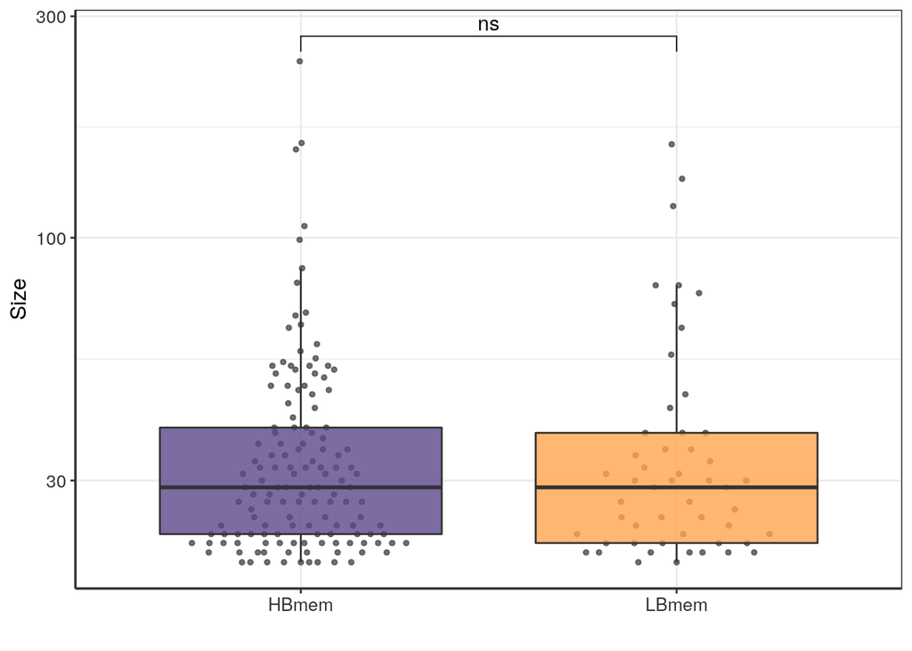

```r
p_size <- ggplot(lineage_composition, aes(x = cluster, y = size, fill = cluster)) +
  geom_quasirandom(width=0.3, size = 1, color = "grey30", alpha = 0.8) +
  geom_boxplot(alpha = 0.8, outlier.colour = NA) +
  stat_compare_means(comparisons = cluster_comparisons, method = "wilcox.test", size = 4, label = "p.signif") +
  scale_y_log10(name=("Size")) +
  scale_x_discrete(name = "") +
  my_colors +
  my_theme

p_size
```

#### Fig. S4D: Spearman’s correlation between the size of the clonal group and its persistence. Statistical significance is the following: * - $p\leq0.05$, ** - $p\leq0.01$, *** - $p\leq10^{-3}$, **** - $p\leq10^{-4}$.

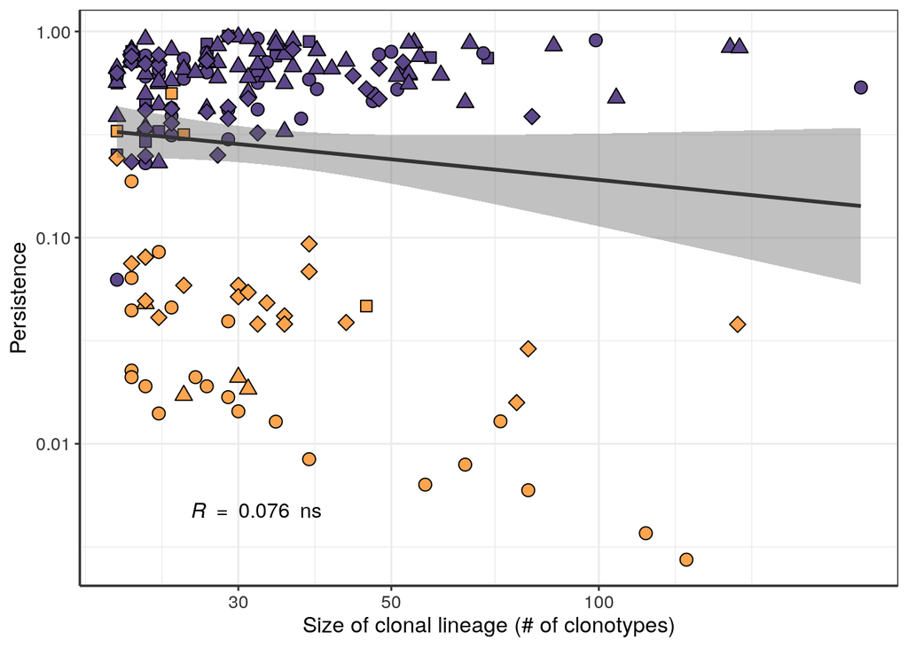

```r
size_pers <- ggplot(lineage_composition, aes(x = size, y = pers)) +
  geom_point(aes(fill = cluster, shape = patient, alpha = cluster), size = 3,  color = "black") +
  geom_smooth(method = 'lm', color = "grey20", fill = "grey40") +
  my_shapes_patients +
  stat_cor(method="spearman", size = 4, label.x.npc = 0.1, label.y.npc = 0.1,
          aes(label = paste(..r.label.., cut(..p.., breaks = c(-Inf, 0.0001, 0.001, 0.01, 0.05, Inf),
                                            labels = c("'****'", "'***'", "'**'", "'*'", "'ns'")),
                            sep = "~"))) +
  my_colors +
  scale_alpha_manual(values = c("2" = 0.7, "1" = 0.5)) +
  scale_y_continuous(trans = "log10", name=("Persistence")) +
  scale_x_continuous(trans = "log10", name = ("Size of clonal lineage (# of clonotypes)")) +
  my_theme
size_pers
```

# Part 2. LBmem clonal groups could arise from HBmem clonal groups.

### (Results from Figure 4)

#### Fig. 4B: Comparison of distances between the germline sequence and the MRCA of a clonal group (G-MRCA distance) for groups of HBmem and LBmem clusters; Level of significance is obtained by the Mann-Whitney test: * - $p\leq0.05$, ** - $p\leq0.01$, *** - $p\leq10^{-3}$, **** - $p\leq10^{-4}$.

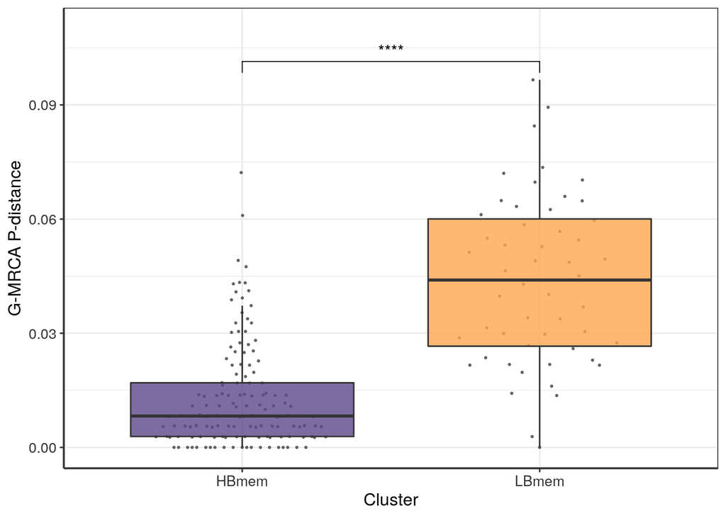

```r
for (i in lineage_composition$file){

    ## g_mrca p-distance
    g_mrca_alig <- read.FASTA(paste0(path, "G-MRCA/", i), type = "DNA")
    g_mrca_alig <- as.character(as.matrix(g_mrca_alig))
    seq_length <- length(g_mrca_alig[1, ])
    g_mrca_alig <- g_mrca_alig[, g_mrca_alig[1,] != "-" & g_mrca_alig[2,] != "-"]
    lineage_composition$g_mrca_dist[lineage_composition$file == i] <-
      sum(g_mrca_alig[1,] != g_mrca_alig[2,]) / seq_length

    ## mean phylogenetic distance
    tr <- read.tree(paste0(path, "trees/RAxML_bestTree.", i, ".out"))
    pairs <- cophenetic.phylo(tr)
    pairs <- pairs[,names(pairs[1,]) != "germline"]
    pairs <- pairs[names(pairs[,1]) != "germline",]
    group_size <- lineage_composition$size[lineage_composition$file == i]
    lineage_composition$phylo_mean_p_dist[lineage_composition$file == i] <-
      sum(pairs)/(group_size*(group_size-1))
}

g_mrca_dist <- ggplot(lineage_composition, aes(x = cluster, y = g_mrca_dist, fill = cluster)) +
  geom_quasirandom(width=0.3, size = 0.4, color = "grey30", alpha = 0.8) +
  geom_boxplot(alpha = 0.8, outlier.colour = NA) +
  stat_compare_means(comparisons = cluster_comparisons, method = "wilcox.test", size = 4, label = "p.signif") +
  scale_y_continuous(name=("G-MRCA P-distance"), limits = c(0, 0.11)) +
  scale_x_discrete(name = "Cluster") +
  my_colors +
  my_theme
g_mrca_dist
```

#### Fig. 4C: Mean pairwise phylogenetic distance, showing genetic divergence of clonotypes of the groups in two clusters; Level of significance is obtained by the Mann-Whitney test: * - $p\leq0.05$, ** - $p\leq0.01$, *** - $p\leq10^{-3}$, **** - $p\leq10^{-4}$.

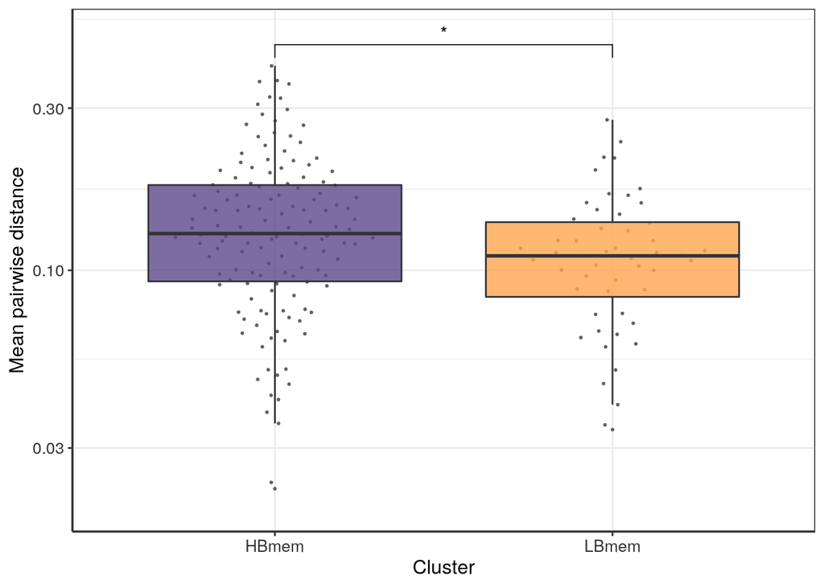

```r
p_mean_dist <- ggplot(lineage_composition, aes(x = cluster, y = phylo_mean_p_dist, fill = cluster)) +
  geom_quasirandom(width=0.3, size = 0.4, color = "grey30", alpha = 0.8) +
  geom_boxplot(alpha = 0.8, outlier.colour = NA) +
  stat_compare_means(comparisons = cluster_comparisons, method = "wilcox.test", size = 4, label = "p.signif") +
  scale_y_log10(name=("Mean pairwise distance"), limits = c(0.02, 0.5)) +
  scale_x_discrete(name = "Cluster") +
  my_colors +
  my_theme
p_mean_dist
```

#### Fig. 4D: Typical representative of phylogenetic trees for clonal groups belonging to HBmem. Circles correspond to individual clonotypes, with the cellular subset indicated by color, and the isotype, by label. The table at the right of each tree indicates the presence or absence of the corresponding clonotype at this time point. The G-MRCA distance is indicated with a thick line.

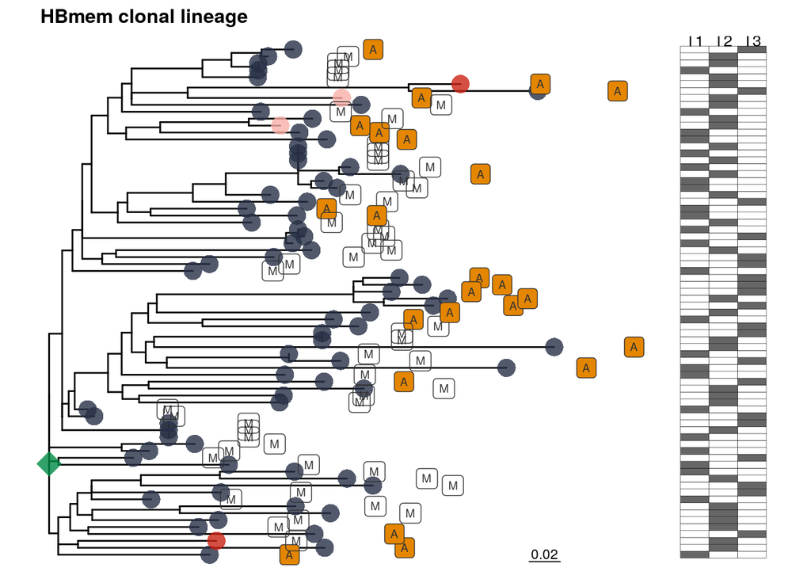

```r
tr_hb <- "IM_clone_39812_size_74_vj.fas"
patient <- "IM"

tree <- unname(unlist(read.table(paste0(path, "trees/RAxML_bestTree.", tr_hb, ".out"))))
tr_repeats <- repeats[repeats$clone == str_remove(tr_hb, "_vj.fas"),]

for (j in 1:nrow(tr_repeats)){
  x <- str_replace_all(tr_repeats$un_names[j], "R", ":0,")
  x <- paste0("(", x, ":0)", sep = "")
  sum_name_j <- str_extract(tr_repeats$sum_name[j], "[0-9]*_5_isot_")
  sum_name_j <- paste0(sum_name_j, "[0-9]*_[A-Z]*_[0-9]*-[0-9]*-[0-9*]")
  tree <- str_replace(tree, sum_name_j, x)
}

germ_branch <- str_extract(tree, ":[0-9].[0-9]*,germline:[0-9].[0-9]*\\);")
tree <- str_replace(tree, ":[0-9].[0-9]*,germline:[0-9].[0-9]*\\);", paste0("G-MRCA", germ_branch))
tree <- str_replace(tree, ",germline", "\\)")
tree <- str_replace(tree, "\\);", ";")

file_tree <- file(paste0(path, "tr_hb_with_repeats"))
writeLines(tree, file_tree)
close(file_tree)

tree <- read.tree(paste0(path, "tr_hb_with_repeats"))
meta <- cbind(tree$tip.label, str_extract(tree$tip.label, "_[A-Z]*_"),
              str_extract(tree$tip.label, "_isot_[0-9]*_"),
              str_extract(tree$tip.label, "201[0-9]*-[0-9]*-[0-9]*"))
meta <- data.frame(meta)
colnames(meta) <- c("tip", "cell", "isot", "date")
rownames(meta) <- tree$tip.label
meta$cell[meta$cell == "__"] <- "_B_"
meta$isot[meta$isot == "_isot_1_"] <- "M"
meta$isot[meta$isot == "_isot_2_"] <- "G"
meta$isot[meta$isot == "_isot_3_"] <- "A"
meta$cell[meta$cell == "NA"] <- "anc. seq."
meta$T1 <- as.numeric(meta$date == timepoints$Date[timepoints$Patient == patient & timepoints$Timepoint == "p01"])
meta$T2 <- as.numeric(meta$date == timepoints$Date[timepoints$Patient == patient & timepoints$Timepoint == "p02"])
meta$T3 <- as.numeric(meta$date == timepoints$Date[timepoints$Patient == patient & timepoints$Timepoint == "p03"])

meta[nrow(meta), c(5,6,7)] <- 0
tree$node.label[which(tree$node.label != "G-MRCA")] <- ""

p_hb <- ggtree(tree, layout = "rectangular") + geom_rootedge(size=1.5) + geom_rootpoint(color = "springgreen4", size = 7, alpha = 0.8, shape = 18)

p_hb <- p_hb %<+% meta +
     geom_tippoint(aes(color=cell),  shape = 16, size=5, alpha=0.8) +
     geom_label(aes(label=isot, size = isot, alpha = isot), position = position_nudge(x = 0.05), color = "grey20",
                fill = "#E58601") +
     #geom_label_repel(aes(label=isot, size = isot, alpha = isot), color = "black", fill = "seagreen") +
     ggtitle("     HBmem clonal lineage") +
     scale_size_manual("Cell Type",
                        values = c("M" = 2.5, "MRCA" = 2, "Germline" = 2, "G" = 2.5, "A" = 2.5)) +
     scale_color_manual("Cell Type",
                        values = c("_B_" = "#273046", "_P_" = "#F8AFA8", "_L_" = "#CB2314",
                                   "_Z_" = "slategray3", "_Y_" = "slategray3"),
                        labels = c("_B_" = "Bmem", "_P_" = "PBL", "_L_" = "PL", "_Z_" = "MRCA", "_Y_" = "Germline")) +
   scale_alpha_manual("Isotype", values = c("M" = 0, "G" = 0.4, "A" = 1, "MRCA" = 0, "Germline" = 0)) +
   geom_treescale(x = 0.3, fontsize=3,  width = 0.02, linesize=0.3)

p_hb <- gheatmap(p_hb, meta[,c(5,6,7)], offset=0.07, width=0.17, low="white", high="grey40", colnames_position = "top", colnames_offset_y = 0.3, font.size=3.5, color="grey10") + theme(legend.position = "none",
                                    plot.title = element_text(colour="black", size = 12, face = "bold"))
p_hb
```

#### Fig. 4E: Typical representative of phylogenetic trees for clonal groups belonging to LBmem. Circles correspond to individual clonotypes, with the cellular subset indicated by color, and the isotype, by label. The table at the right of each tree indicates the presence or absence of the corresponding clonotype at this time point. The G-MRCA distance is indicated with a thick line.

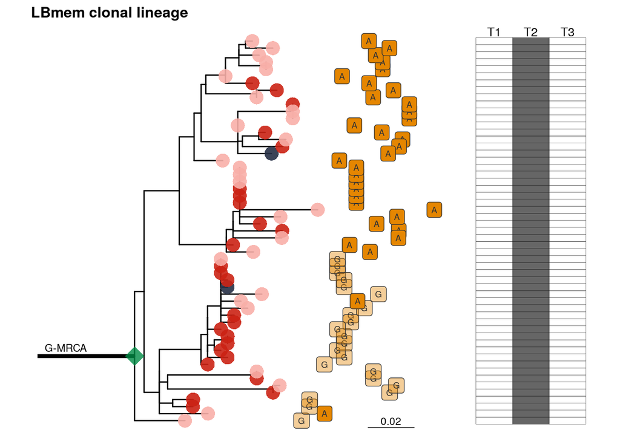

```r
tr_lb <- "MRK_clone_13788_size_55_vj.fas"
patient <- "MRK"

tree <- unname(unlist(read.table(paste0(path, "trees/RAxML_bestTree.", tr_lb, ".out"))))
tr_repeats <- repeats[repeats$clone == str_remove(tr_lb, "_vj.fas"),]

for (j in 1:nrow(tr_repeats)){
  x <- str_replace_all(tr_repeats$un_names[j], "R", ":0,")
  x <- paste0("(", x, ":0)", sep = "")
  sum_name_j <- str_extract(tr_repeats$sum_name[j], "[0-9]*_5_isot_")
  sum_name_j <- paste0(sum_name_j, "[0-9]*_[A-Z]*_[0-9]*-[0-9]*-[0-9*]")
  tree <- str_replace(tree, sum_name_j, x)
}

germ_branch <- str_extract(tree, ":[0-9].[0-9]*,germline:[0-9].[0-9]*\\);")
tree <- str_replace(tree, ":[0-9].[0-9]*,germline:[0-9].[0-9]*\\);", paste0("G-MRCA", germ_branch))
tree <- str_replace(tree, "G-MRCA:[0-9].[0-9]*", "G-MRCA:0")
tree <- str_replace(tree, ",germline", "\\)")
tree <- str_replace(tree, "\\);", ";")

file_tree <- file(paste0(path, "tr_lb_with_repeats"))
writeLines(tree, file_tree)
close(file_tree)

tree <- read.tree(paste0(path, "tr_lb_with_repeats"))
meta <- cbind(tree$tip.label, str_extract(tree$tip.label, "_[A-Z]*_"),
              str_extract(tree$tip.label, "_isot_[0-9]*_"),
              str_extract(tree$tip.label, "201[0-9]*-[0-9]*-[0-9]*"))
meta <- data.frame(meta)
colnames(meta) <- c("tip", "cell", "isot", "date")
rownames(meta) <- tree$tip.label
meta$cell[meta$cell == "__"] <- "_B_"
meta$isot[meta$isot == "_isot_1_"] <- "M"
meta$isot[meta$isot == "_isot_2_"] <- "G"
meta$isot[meta$isot == "_isot_3_"] <- "A"
meta$cell[meta$cell == "NA"] <- "anc. seq."
meta$T1 <- as.numeric(meta$date == timepoints$Date[timepoints$Patient == patient & timepoints$Timepoint == "p01"])
meta$T2 <- as.numeric(meta$date == timepoints$Date[timepoints$Patient == patient & timepoints$Timepoint == "p02"])
#meta$T2 <- rep(1, nrow(meta))
meta$T3 <- as.numeric(meta$date == timepoints$Date[timepoints$Patient == patient & timepoints$Timepoint == "p03"])
meta$T2[nrow(meta)] <- 1
tree$node.label[which(tree$node.label != "G-MRCA")] <- ""

p_lb <- ggtree(tree, layout = "rectangular") + geom_rootedge(size = 1.5) + geom_rootpoint(color = "springgreen4", size = 7, alpha = 0.8, shape = 18)  +
   geom_nodelab(nudge_x = -0.03, nudge_y = 1.2, size = 3)

p_lb <- p_lb %<+% meta +
     geom_tippoint(aes(color=cell),  shape = 16, size=5, alpha=0.9) +
     geom_label(aes(label=isot, size = isot, alpha = isot), position = position_nudge(x = 0.05), color = "grey20",
                fill = "#E58601") +
     #geom_label_repel(aes(label=isot, size = isot, alpha = isot), color = "black", fill = "seagreen") +
     ggtitle("     LBmem clonal lineage") +
     scale_size_manual("Cell Type",
                        values = c("M" = 2.5, "MRCA" = 2, "Germline" = 2, "G" = 2.5, "A" = 2.5)) +
     scale_color_manual("Cell Type",
                        values = c("_B_" = "#273046", "_P_" = "#F8AFA8", "_L_" = "#CB2314",
                                   "_Z_" = "grey40", "_Y_" = "black"),
                        labels = c("_B_" = "Bmem", "_P_" = "PBL", "_L_" = "PL", "_Z_" = "MRCA", "_Y_" = "Germline")) +
   scale_alpha_manual("Isotype", values = c("M" = 0, "G" = 0.4, "A" = 1, "MRCA" = 0, "Germline" = 0)) +
   geom_treescale(x = 0.1, width = 0.02, fontsize=3, linesize=0.3)

p_lb1 <- p_lb
p_lb <- gheatmap(p_lb, meta[,c(5,6,7)], offset=0.06, width=0.6, low="white", high="grey40", colnames_position = "top", colnames_offset_y = 0.3, font.size=3.5, color="grey10") + theme(legend.position = "none",
                                                                                                                                                             plot.title = element_text(colour="black", size = 12, face = "bold"))
p_lb
```